# CA0 - Mohammad Hosein Aghili - 810199576

1-

```python
import pandas as pd
import numpy as np
import matplotlib.pyplot as plt
import scipy as sp
import scipy.stats as stats


data = pd.read_csv('train.csv')
```

describe method: this method show us some information about numerical type columns count show us number of non-Nan values. mean show us mean. std show us standard deviation. max and min show us maximum and minimum. 25%,50%,75% show us percentiles.

```python
display(data.describe())
```

|  | age | fnlwgt | education-num | capital-gain | capital-loss | hours-per-week |
| --- | --- | --- | --- | --- | --- | --- |
| count | 29825.000000 | 2.982500e+04 | 29825.000000 | 29825.000000 | 29825.000000 | 29825.000000 |
| mean | 38.581425 | 1.897389e+05 | 10.079229 | 1094.586052 | 86.476513 | 40.434334 |
| std | 13.652005 | 1.053738e+05 | 2.571678 | 7485.908646 | 401.195078 | 12.308174 |
| min | 17.000000 | 1.228500e+04 | 1.000000 | 0.000000 | 0.000000 | 1.000000 |
| 25% | 28.000000 | 1.178490e+05 | 9.000000 | 0.000000 | 0.000000 | 40.000000 |
| 50% | 37.000000 | 1.785170e+05 | 10.000000 | 0.000000 | 0.000000 | 40.000000 |
| 75% | 48.000000 | 2.368790e+05 | 12.000000 | 0.000000 | 0.000000 | 45.000000 |
| max | 90.000000 | 1.484705e+06 | 16.000000 | 99999.000000 | 4356.000000 | 99.000000 |

tail and head methods give us n as input and show n first and last of data.

```python
print("tail:")
display(data.tail(10))
print("\nhead:")
display(data.head(10))
```

```
tail:
```

|  | age | workclass | fnlwgt | education | education-num | marital-status | occupation | relationship | race | sex | capital-gain | capital-loss | hours-per-week | native-country | salary |
| --- | --- | --- | --- | --- | --- | --- | --- | --- | --- | --- | --- | --- | --- | --- | --- |
| 29815 | 32 | Private | 48520 | Some-college | 10 | Married-civ-spouse | Craft-repair | Husband | White | Male | 0 | 0 | 40 | United-States | <=50K |
| 29816 | 19 | Self-emp-inc | 170125 | HS-grad | 9 | Never-married | Sales | Own-child | White | Male | 0 | 0 | 40 | United-States | <=50K |
| 29817 | 41 | Private | 107584 | HS-grad | 9 | Married-civ-spouse | Machine-op-inspct | Husband | White | Male | 0 | 0 | 40 | United-States | <=50K |
| 29818 | 24 | Private | 196742 | HS-grad | 9 | Divorced | Other-service | Unmarried | White | Female | 0 | 0 | 40 | United-States | <=50K |
| 29819 | 52 | NaN | 244214 | HS-grad | 9 | Married-civ-spouse | NaN | Husband | White | Male | 0 | 0 | 35 | United-States | <=50K |
| 29820 | 48 | Local-gov | 127921 | Bachelors | 13 | Married-civ-spouse | Prof-specialty | Husband | White | Male | 0 | 0 | 40 | United-States | <=50K |
| 29821 | 32 | Private | 42617 | Some-college | 10 | Divorced | Prof-specialty | Not-in-family | White | Female | 0 | 0 | 30 | United-States | <=50K |
| 29822 | 47 | Local-gov | 191389 | HS-grad | 9 | Divorced | Adm-clerical | Unmarried | White | Female | 0 | 0 | 35 | United-States | <=50K |
| 29823 | 38 | Private | 187983 | Prof-school | 15 | Married-civ-spouse | Sales | Wife | White | Female | 0 | 0 | 40 | United-States | <=50K |
| 29824 | 18 | Private | 215110 | HS-grad | 9 | Never-married | Handlers-cleaners | Own-child | Black | Male | 0 | 0 | 40 | United-States | <=50K |

```
head:
```

|  | age | workclass | fnlwgt | education | education-num | marital-status | occupation | relationship | race | sex | capital-gain | capital-loss | hours-per-week | native-country | salary |
| --- | --- | --- | --- | --- | --- | --- | --- | --- | --- | --- | --- | --- | --- | --- | --- |
| 0 | 39 | State-gov | 77516 | Bachelors | 13 | Never-married | Adm-clerical | Not-in-family | White | Male | 2174 | 0 | 40 | United-States | <=50K |
| 1 | 50 | Self-emp-not-inc | 83311 | Bachelors | 13 | Married-civ-spouse | Exec-managerial | Husband | White | Male | 0 | 0 | 13 | United-States | <=50K |
| 2 | 38 | Private | 215646 | HS-grad | 9 | Divorced | Handlers-cleaners | Not-in-family | White | Male | 0 | 0 | 40 | United-States | <=50K |
| 3 | 53 | Private | 234721 | 11th | 7 | Married-civ-spouse | Handlers-cleaners | Husband | Black | Male | 0 | 0 | 40 | United-States | <=50K |
| 4 | 28 | Private | 338409 | Bachelors | 13 | Married-civ-spouse | Prof-specialty | Wife | Black | Female | 0 | 0 | 40 | Cuba | <=50K |
| 5 | 37 | Private | 284582 | Masters | 14 | Married-civ-spouse | Exec-managerial | Wife | White | Female | 0 | 0 | 40 | United-States | <=50K |
| 6 | 49 | Private | 160187 | 9th | 5 | Married-spouse-absent | Other-service | Not-in-family | Black | Female | 0 | 0 | 16 | Jamaica | <=50K |
| 7 | 52 | Self-emp-not-inc | 209642 | HS-grad | 9 | Married-civ-spouse | Exec-managerial | Husband | White | Male | 0 | 0 | 45 | United-States | >50K |
| 8 | 31 | Private | 45781 | Masters | 14 | Never-married | Prof-specialty | Not-in-family | White | Female | 14084 | 0 | 50 | United-States | >50K |
| 9 | 42 | Private | 159449 | Bachelors | 13 | Married-civ-spouse | Exec-managerial | Husband | White | Male | 5178 | 0 | 40 | United-States | >50K |

info method: this method show us some information as see below.

```python
display(data.info())
data.isna().sum()
```

```
<class 'pandas.core.frame.DataFrame'>
RangeIndex: 29825 entries, 0 to 29824
Data columns (total 15 columns):
 #   Column          Non-Null Count  Dtype
---  ------          --------------  -----
 0   age             29825 non-null  int64
 1   workclass       28154 non-null  object
 2   fnlwgt          29825 non-null  int64
 3   education       29825 non-null  object
 4   education-num   29825 non-null  int64
 5   marital-status  29825 non-null  object
 6   occupation      28149 non-null  object
 7   relationship    29825 non-null  object
 8   race            29825 non-null  object
 9   sex             29825 non-null  object
 10  capital-gain    29825 non-null  int64
 11  capital-loss    29825 non-null  int64
 12  hours-per-week  29825 non-null  int64
 13  native-country  29288 non-null  object
 14  salary          29825 non-null  object
dtypes: int64(6), object(9)
memory usage: 3.4+ MB
```

```
None
```

```
age                  0
workclass         1671
fnlwgt               0
education            0
education-num        0
marital-status       0
occupation        1676
relationship         0
race                 0
sex                  0
capital-gain         0
capital-loss         0
hours-per-week       0
native-country     537
salary               0
dtype: int64
```

2- Dtype of each object shown above.

```python
Sex = {'Male': 0, 'Female': 1}
Salary = {'<=50K': 0, '>50K': 1}

data['sex'].replace(Sex, inplace=True)
data['salary'].replace(Salary, inplace=True)
data['race'] = data['race'].astype('category')
data['relationship'] = data['relationship'].astype('category')
data['marital-status'] = data['marital-status'].astype('category')
data['occupation'] = data['occupation'].astype('category')
data['education'] = data['education'].astype('category')
data['occupation'] = data['occupation'].astype('category')
data['native-country'] = data['native-country'].astype('category')
data['workclass'] = data['workclass'].astype('category')
cat_columns = data.select_dtypes(['category']).columns
cat_columns
data[cat_columns] = data[cat_columns].apply(lambda x: x.cat.codes)




# data.dtypes

#showing result
data.head(10)
```

|  | age | workclass | fnlwgt | education | education-num | marital-status | occupation | relationship | race | sex | capital-gain | capital-loss | hours-per-week | native-country | salary |
| --- | --- | --- | --- | --- | --- | --- | --- | --- | --- | --- | --- | --- | --- | --- | --- |
| 0 | 39 | 6 | 77516 | 9 | 13 | 4 | 0 | 1 | 4 | 0 | 2174 | 0 | 40 | 38 | 0 |
| 1 | 50 | 5 | 83311 | 9 | 13 | 2 | 3 | 0 | 4 | 0 | 0 | 0 | 13 | 38 | 0 |
| 2 | 38 | 3 | 215646 | 11 | 9 | 0 | 5 | 1 | 4 | 0 | 0 | 0 | 40 | 38 | 0 |
| 3 | 53 | 3 | 234721 | 1 | 7 | 2 | 5 | 0 | 2 | 0 | 0 | 0 | 40 | 38 | 0 |
| 4 | 28 | 3 | 338409 | 9 | 13 | 2 | 9 | 5 | 2 | 1 | 0 | 0 | 40 | 4 | 0 |
| 5 | 37 | 3 | 284582 | 12 | 14 | 2 | 3 | 5 | 4 | 1 | 0 | 0 | 40 | 38 | 0 |
| 6 | 49 | 3 | 160187 | 6 | 5 | 3 | 7 | 1 | 2 | 1 | 0 | 0 | 16 | 22 | 0 |
| 7 | 52 | 5 | 209642 | 11 | 9 | 2 | 3 | 0 | 4 | 0 | 0 | 0 | 45 | 38 | 1 |
| 8 | 31 | 3 | 45781 | 12 | 14 | 4 | 9 | 1 | 4 | 1 | 14084 | 0 | 50 | 38 | 1 |
| 9 | 42 | 3 | 159449 | 9 | 13 | 2 | 3 | 0 | 4 | 0 | 5178 | 0 | 40 | 38 | 1 |

as you can see we encode sex and salary to number, by setting 0 for male and set 1 for female

3-

count of NaN values:

```python
data.isna().sum()
```

```
age               0
workclass         0
fnlwgt            0
education         0
education-num     0
marital-status    0
occupation        0
relationship      0
race              0
sex               0
capital-gain      0
capital-loss      0
hours-per-week    0
native-country    0
salary            0
dtype: int64
```

```python
data.info()
```

```
<class 'pandas.core.frame.DataFrame'>
RangeIndex: 29825 entries, 0 to 29824
Data columns (total 15 columns):
 #   Column          Non-Null Count  Dtype
---  ------          --------------  -----
 0   age             29825 non-null  int64
 1   workclass       29825 non-null  int8
 2   fnlwgt          29825 non-null  int64
 3   education       29825 non-null  int8
 4   education-num   29825 non-null  int64
 5   marital-status  29825 non-null  int8
 6   occupation      29825 non-null  int8
 7   relationship    29825 non-null  int8
 8   race            29825 non-null  int8
 9   sex             29825 non-null  int64
 10  capital-gain    29825 non-null  int64
 11  capital-loss    29825 non-null  int64
 12  hours-per-week  29825 non-null  int64
 13  native-country  29825 non-null  int8
 14  salary          29825 non-null  int64
dtypes: int64(8), int8(7)
memory usage: 2.0 MB
```

4- dropping fnlwgt because they're unique for every row

```python
data.drop('fnlwgt', axis=1, inplace=True)
```

```python
data.head()
```

|  | age | workclass | education | education-num | marital-status | occupation | relationship | race | sex | capital-gain | capital-loss | hours-per-week | native-country | salary |
| --- | --- | --- | --- | --- | --- | --- | --- | --- | --- | --- | --- | --- | --- | --- |
| 0 | 39 | 6 | 9 | 13 | 4 | 0 | 1 | 4 | 0 | 2174 | 0 | 40 | 38 | 0 |
| 1 | 50 | 5 | 9 | 13 | 2 | 3 | 0 | 4 | 0 | 0 | 0 | 13 | 38 | 0 |
| 2 | 38 | 3 | 11 | 9 | 0 | 5 | 1 | 4 | 0 | 0 | 0 | 40 | 38 | 0 |
| 3 | 53 | 3 | 1 | 7 | 2 | 5 | 0 | 2 | 0 | 0 | 0 | 40 | 38 | 0 |
| 4 | 28 | 3 | 9 | 13 | 2 | 9 | 5 | 2 | 1 | 0 | 0 | 40 | 4 | 0 |

5- using loc method

```python
malenum = data.loc[data.sex == Sex['Male']].shape[0]
print("number of male:",malenum)
femalenum= data.loc[data.sex == Sex['Female']].shape[0]
print("number of female:",femalenum)
Mnum=data.loc[(data['marital-status'] == 1)].shape[0]
print("number of Married-civ-spouse:" , Mnum)
```

[output not shown]

```python
data.loc[
    (data['age'] > 30) &
    (data['race'] == 2) &
    (data['workclass'] == 4)
].shape[0]
```

```
16
```

7- calculate with vectorization: Average hours of for who has Bachelors

```python
import time

start_vec = time.time()
def calc_mean_vec():
    return data[data['education'] == 9]['hours-per-week'].mean()

print('mean : ', calc_mean_vec())

end_vec = time.time()
```

```
mean :  42.546669366268475
```

8- calculate mean using for loop:

```python
start_loop = time.time()


def forLoopMean():
    sum = 0
    count = 0
    for index, row in data.iterrows():
        if row['education'] == 9:
            sum += row['hours-per-week']
            count += 1
    return sum / count

print('mean : ', forLoopMean())
end_loop = time.time()
```

```
mean :  42.546669366268475
```

As you can see vectoziation is too much faster:

```python
print("time spent for vectozation :",end_vec - start_vec)
print("time spent for loop :",end_loop - start_loop)
```

```
time spent for vectozation : 0.0034279823303222656
time spent for loop : 0.9577012062072754
```

As you can see vectoziation is too much faster.

9-hist method:

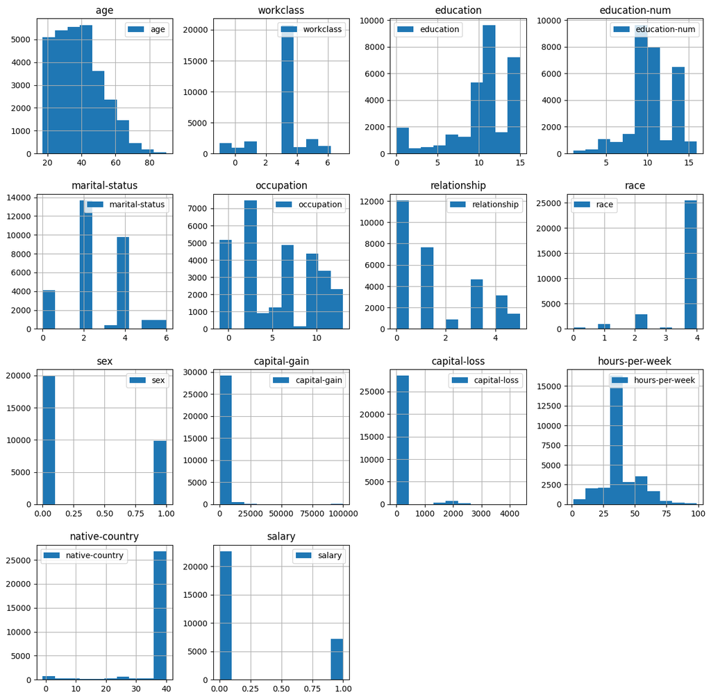

```python
data.hist(figsize=(15, 15), legend=True);
```

10-subtracting mean and dividing by std:

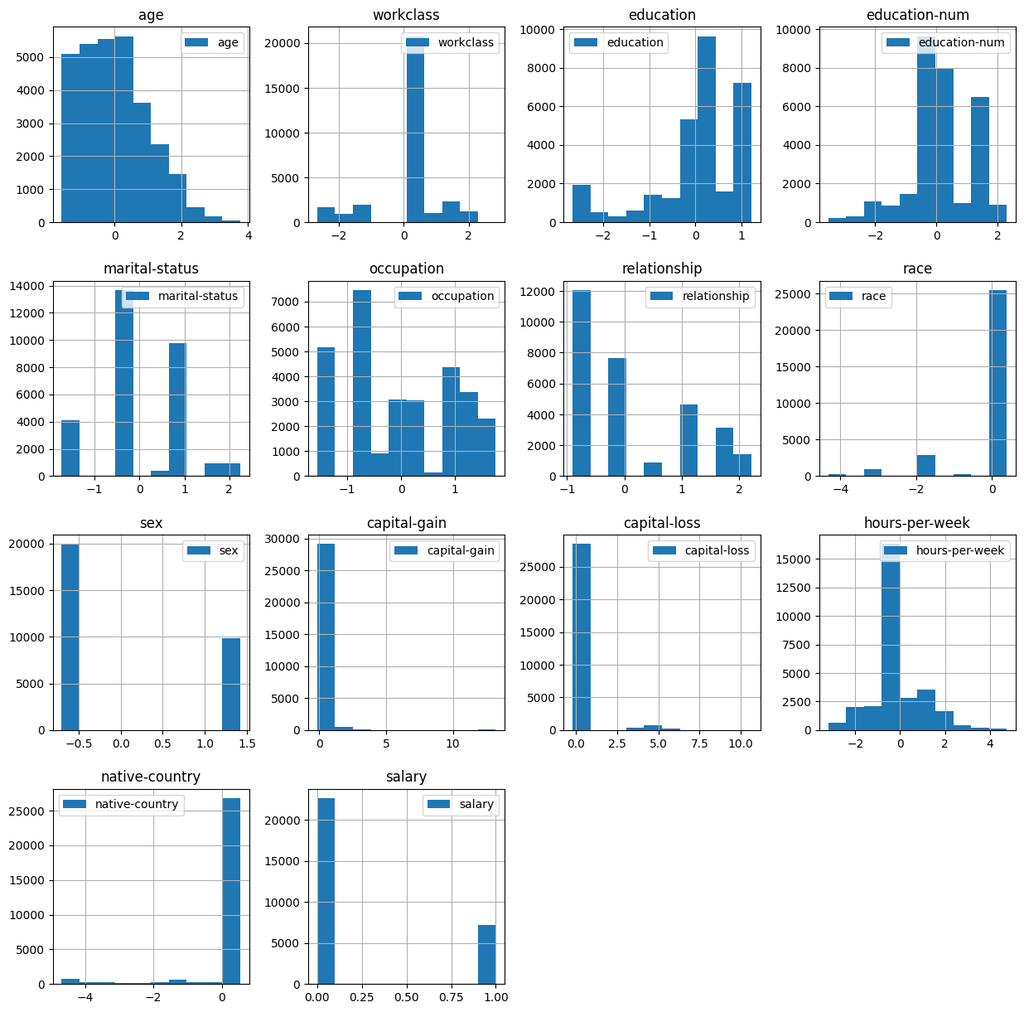

```python
data_copy = data.copy()
data_copy.drop('salary', axis=1, inplace=True)
data_copy = (data_copy - data_copy.mean(numeric_only=True)) / data_copy.std(numeric_only=True)
data_copy['salary'] = data['salary']
data_copy.hist(figsize=(15, 15), legend=True);
```

11-

```python
def calc_Mean_Std(data_):
    return data_.mean(numeric_only=True), data_.std(numeric_only=True)
More50 = data_copy.loc[data_copy.salary == 1].drop('salary', axis=1)
more50_mean, more50_std = calc_Mean_Std(More50)
less50 = data_copy.loc[data_copy.salary == 0].drop('salary', axis=1)
less50_mean, less50_std = calc_Mean_Std(less50)

data_map = pd.DataFrame({
    '>50K_Mean': more50_mean,
    '>50k_Std': more50_std,
    '<=50k_Mean': less50_mean,
    '<=50k_Std': less50_std
})
display(data_map)
```

|  | >50K_Mean | >50k_Std | <=50k_Mean | <=50k_Std |
| --- | --- | --- | --- | --- |
| age | 0.414559 | 0.771200 | -0.130817 | 1.027893 |
| workclass | 0.096887 | 0.968683 | -0.030573 | 1.007770 |
| education | 0.134591 | 0.734637 | -0.042471 | 1.066660 |
| education-num | 0.594376 | 0.931544 | -0.187560 | 0.946097 |
| marital-status | -0.353505 | 0.566432 | 0.111551 | 1.078173 |
| occupation | 0.136967 | 0.971080 | -0.043221 | 1.005108 |
| relationship | -0.445503 | 0.984013 | 0.140582 | 0.963149 |
| race | 0.130958 | 0.859712 | -0.041325 | 1.036940 |
| sex | -0.385660 | 0.757705 | 0.121698 | 1.035700 |
| capital-gain | 0.399265 | 1.976087 | -0.125991 | 0.131465 |
| capital-loss | 0.261746 | 1.473212 | -0.082596 | 0.776095 |
| hours-per-week | 0.406811 | 0.887465 | -0.128372 | 0.999179 |
| native-country | 0.029586 | 0.979308 | -0.009336 | 1.006282 |